# R-Script for Pre-Registration Experiment 1a: Direct evalautive ratings

### Predicted values by model:

```
##                                  Estimate Std. Error     t value
## (Intercept)                    64.9108911   6.095215 10.64948407
## type_discreteGS               -40.3003300   4.755392 -8.47465946
## conditionmany                  -0.7492749   8.663361 -0.08648779
## type_discreteGS:conditionmany  22.9114411   6.759020  3.38975773
```

```
##       diff type_discrete
## 1 64.16162            CS
## 2 46.77273            GS
```

Observed Results:

```
##   condition type_discrete     diff       se
## 1       one            CS 64.91089 5.529529
## 2      many            CS 64.16162 5.021323
## 3       one            GS 24.61056 2.848193
## 4      many            GS 46.77273 2.739109
```

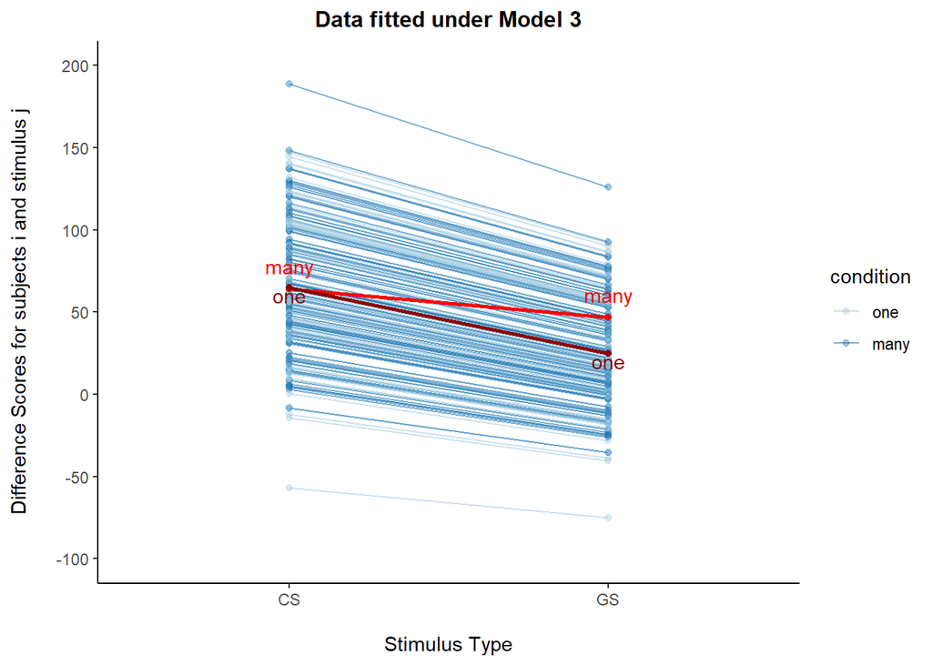

```r
#simple slopes
CSs <- lm (diff ~ condition, HLM[HLM$type_discrete == "CS",])
summary(CSs) #400 observations
```

```
##
## Call:
## lm(formula = diff ~ condition, data = HLM[HLM$type_discrete ==
##     "CS", ])
##
## Residuals:
##      Min       1Q   Median       3Q      Max
## -263.911  -55.911    6.464   55.276  135.838
##
## Coefficients:
##               Estimate Std. Error t value Pr(>|t|)
## (Intercept)    64.9109     5.2607   12.34   <2e-16 ***
## conditionmany  -0.7493     7.4772   -0.10     0.92
## ---
## Signif. codes:  0 '***' 0.001 '**' 0.01 '*' 0.05 '.' 0.1 ' ' 1
##
## Residual standard error: 74.77 on 398 degrees of freedom
## Multiple R-squared:  2.523e-05,  Adjusted R-squared:  -0.002487
## F-statistic: 0.01004 on 1 and 398 DF,  p-value: 0.9202
```

```r
GSs <- lm (diff ~ condition, HLM[HLM$type_discrete == "GS", ])
summary(GSs) #1200 observations -> ? higher power in this condition
```

```
##
## Call:
## lm(formula = diff ~ condition, data = HLM[HLM$type_discrete ==
##     "GS", ])
##
## Residuals:
##      Min       1Q   Median       3Q      Max
## -222.773  -45.651   -1.773   50.389  175.389
##
## Coefficients:
##               Estimate Std. Error t value Pr(>|t|)
## (Intercept)     24.611      2.782   8.848  < 2e-16 ***
## conditionmany   22.162      3.954   5.606 2.57e-08 ***
## ---
## Signif. codes:  0 '***' 0.001 '**' 0.01 '*' 0.05 '.' 0.1 ' ' 1
##
## Residual standard error: 68.47 on 1198 degrees of freedom
## Multiple R-squared:  0.02556,    Adjusted R-squared:  0.02475
## F-statistic: 31.42 on 1 and 1198 DF,  p-value: 2.573e-08
```

Interpretation:

**H1a:** (CSs not significant) In line with the prediction that condition does not impact evaluations of CSs

**H2a:** (GSs significant) In line with the prediction that condition impacts evaluations of GSs, the positive value indicates that difference scores are higher in the “many” condition than in the “one” condition for GSs

-> calculation of simple slopes does not bring additional information in this case

## (2) Testing H2: CS Components

### Hypothesis 2:

Evaluative ratings differ between predictive and non-predictive components for “many” condition. No difference between the components in the “one” condition.

Explanation: In the „many“ condition, the EC effect gets attached to the category-defining feature, while in the „one“ condition, the EC effect gets attached to the whole stimulus

Dummy Coded: Stimulus Component (0 - Non-Predictive , 1 - Predictive) and Condition (0 - One, 1 - Many)

(2a) *non-significant fixed effect of stimulus component, when ref. category is “one”*

-> no difference between components in **“one” condition**

(2b) *significant fixed effect for the cross-level interaction stimulus component x condition, and fixed effect of condition, when ref. category is “one”.*

-> difference between components in **many condition** goes beyond difference in components in “one” condition *-> confirms the hypothesis only indirectly…*

### Plot raw data [predictive, non-predictive is hypothetical]:

```
##   type_discrete condition     diff       se
## 1    predictive       one 22.80198 4.657714
## 2    predictive      many 43.11616 5.220003
```

```
##    type_discrete condition     diff       se
## 1     predictive       one 22.80198 4.657714
## 2     predictive      many 43.11616 5.220003
## 3 non-predictive      many 18.00000 0.000000
## 4 non-predictive       one 22.00000 0.000000
```

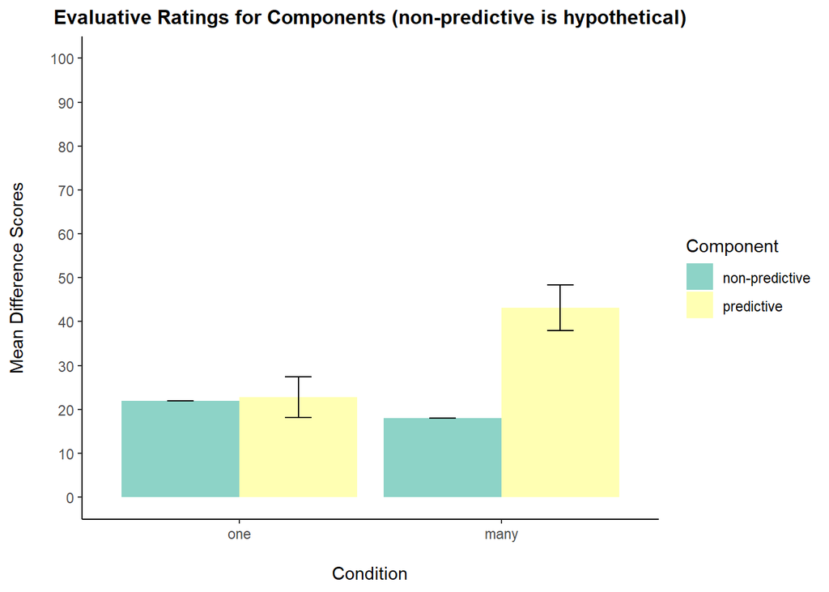